# R Notebook - Meta-analysis by Louise M. Alissa (Male Competition)

**ALISSA, L.M. Effect of reproductive site limitation on the intensity of sexual selection and the quality of paternal care: a meta-analysis. 2018. Dissertação (Mestrado) - Instituto de Biociências, Universidade de São Paulo, SP.**

The availability of reproductive sites is a major factor shaping the behavior of males and females in species with resource-based mating systems. Using a meta-analytic approach, we tested five predictions directly or indirectly derived from the mating system theory. We expected that reproductive site limitation would lead to: (1) intense male-male competition for resource possession; (2) high variance in male reproductive success, generating high values of opportunity for sexual selection; (3) high intensity of selection on male traits related to resource possession; (4) high sperm competition risk; and (5) low quality of paternal care. We compiled information from observational and experimental studies that compared the reproductive behavior of individuals of the same species under low and high reproductive site limitation. We found that, when reproductive sites are limited, there is a slight increase in male-male competition, with higher rates of nest takeover and agonistic interactions, and a slight increase in the selection gradient on male traits, with successful males tending to be larger than unsuccessful males. Reproductive site limitation has no consistent effect on the opportunity for sexual selection and on the sperm competition risk. However, territorial males invest more in gonads and lose less paternity when reproductive sites are limited. There is also no clear effect of reproductive site limitation on the quality of paternal care, but few studies have addressed this subject. Taken together, our findings indicate that predictions on how reproductive site limitation affects several aspects of resource-based mating systems have weak empirical support. These predictions do not consider the plasticity in the mating tactics of males and females, which make them too simplistic. Moreover, since the original proposition of the mating system theory, our understanding of sperm competition increased a lot. We now know that accurate predictions on the intensity and direction of sexual selection should take into account both pre- and post-copulatory processes. Finally, the interplay between sexual selection and parental care is complex, and the original framework of mating system theory does not provide sufficient elements to derive clear and taxonomically broad predictions.

Louise Alissa de Morais

e-mail: louisem.alissa@gmail.com

# Organizing

## Loading libraries, setting working directory and loading data set

### Setting the work directory

```r
setwd("C:/Users/louis/Dropbox/Masters_analyses-LMAlissa")
```

### Opening packages

```r
library(metafor)
library(ggplot2)
library(phytools)
library(geiger)
library(picante)
library(MuMIn)
library(car)
library(ape)
library(Hmisc)
library(miscTools)
library(bbmle)
```

### Cleanning possible masking objects

```r
rm(list=ls())
```

### Opening the .csv file

```r
dataset1 <- read.csv(file="basic_dataset1.csv", header=T, dec=".", sep=";")
```

### Looking to data structure

```r
head(dataset1)
```

|  | ES | nID | study | publication_year | species | phylo | class | order | taxon | mating_system | care | exploited_resource | study_type | nest_availability_difference | resource_facet_manipulated | pred | response_variable | r | N |
| --- | --- | --- | --- | --- | --- | --- | --- | --- | --- | --- | --- | --- | --- | --- | --- | --- | --- | --- | --- |
| 1 | E.S. 01 | 4 | Borgia 1980 | 1980 | Scatophaga stercoraria | Scatophaga_stercoraria | Insecta | Diptera | 1_artro | polygamy | no_care | pats of cow | exp_field | yes | quant | dir | attacked male leaves/Attacks (number of males that leaves after attack) | -0.5485800 | 758 |
| 2 | E.S. 02 | 4 | Borgia 1980 | 1980 | Scatophaga stercoraria | Scatophaga_stercoraria | Insecta | Diptera | 1_artro | polygamy | no_care | pats of cow | exp_field | yes | quant | dir | attack duration (sec) | 0.9900000 | 154 |
| 3 | E.S. 03 | 4 | Borgia 1980 | 1980 | Scatophaga stercoraria | Scatophaga_stercoraria | Insecta | Diptera | 1_artro | polygamy | no_care | pats of cow | exp_field | yes | quant | dir | attacks/Encounters (number of attacks controled by the number of male encounters) | -0.4692073 | 1194 |
| 4 | E.S. 04 | 11 | Debuse et al 2003 | 2003 | Homarus gammarus | Homarus_gammarus | Malacostraca | Decapoda | 1_artro | polygamy | maternal | rock crevices | exp_lab | yes | quant | dir | frequency of attack (log) | 0.1690000 | 30 |
| 5 | E.S. 05 | 11 | Debuse et al 2003 | 2003 | Homarus gammarus | Homarus_gammarus | Malacostraca | Decapoda | 1_artro | polygamy | maternal | rock crevices | exp_lab | yes | quant | dir | mean duration of attack (min) | -0.3590000 | 30 |
| 6 | E.S. 06 | 46 | Werneck and Machado unpublished | unp | Magnispina neptunus | Magnispina_neptunus | Arachnida | Opiliones | 1_artro | polygamy | paternal | natural cavities in roadside banks | exp_lab | yes | quant | ind | nest occupancy | 0.2790000 | 84 |

```r
tail(dataset1)
```

|  | ES | nID | study | publication_year | species | phylo | class | order | taxon | mating_system | care | exploited_resource | study_type | nest_availability_difference | resource_facet_manipulated | pred | response_variable | r | N |
| --- | --- | --- | --- | --- | --- | --- | --- | --- | --- | --- | --- | --- | --- | --- | --- | --- | --- | --- | --- |
| 46 | E.S. 46 | 52 | Oliveira et al 2000 | 2000 | Parablennius sanguinolentus | Parablennius_sanguinolentus | Actinopterygii | Perciformes | 2_pisc | polygamy | paternal | natural crevices | obs | yes | qualit | dir | attacks towards conspecifcs (acts/hour) | -0.01909504 | 24 |
| 47 | E.S. 47 | 53 | Jones et al 2001 | 2001 | Pomatoschistus minutus | Pomatoschistus_minutus | Actinopterygii | Perciformes | 2_pisc | polygamy | paternal | shells and crevices | obs | yes | quant | ind | artificial nest site colonization | 0.39165075 | 150 |
| 48 | E.S. 48 | 16 | Gowaty and Bridges 1991 | 1991 | Sialia sialis | Sialia_sialis | Aves | Passeriformes | 4_ave | monogamy | biparental | tree hollows and nest box | exp_field | yes | dispo | ind | nest occupancy | 0.29780434 | 102 |
| 49 | E.S. 49 | 13 | Duckworth 2006 | 2006 | Sialia mexicana | Sialia_mexicana | Aves | Passeriformes | 4_ave | monogamy | biparental | tree hollows and nest box | exp_field | yes | qualit | dir | male agression index | 0.33800000 | 27 |
| 50 | E.S. 50 | 13 | Duckworth 2006 | 2006 | Sialia mexicana | Sialia_mexicana | Aves | Passeriformes | 4_ave | monogamy | biparental | tree hollows and nest box | exp_field | yes | qualit | dir | male agression index | 0.00500000 | 31 |
| 51 | E.S. 51 | 20 | Jacot et al 2009 | 2009 | Cyanistes caeruleus | Cyanistes_caeruleus | Aves | Passeriformes | 4_ave | polygamy | biparental | tree hollows and nest box | exp_field | yes | quant | ind | occupation rate | 0.13190628 | 58 |

```r
str(dataset1)
```

```
'data.frame':   51 obs. of  19 variables:
 $ ES                          : Factor w/ 51 levels "E.S. 01","E.S. 02",..: 1 2 3 4 5 6 7 8 9 10 ...
 $ nID                         : int  4 4 4 11 11 46 46 46 14 14 ...
 $ study                       : Factor w/ 25 levels "Bessert et al 2007",..: 3 3 3 6 6 25 25 25 9 9 ...
 $ publication_year            : Factor w/ 17 levels "1980","1991",..: 1 1 1 8 8 17 17 17 4 4 ...
 $ species                     : Factor w/ 20 levels "Archocentrus nigrofasciatus",..: 17 17 17 5 5 6 6 6 11 11 ...
 $ phylo                       : Factor w/ 20 levels "Archocentrus_nigrofasciatus",..: 17 17 17 5 5 6 6 6 11 11 ...
 $ class                       : Factor w/ 5 levels "Actinopterygii",..: 4 4 4 5 5 2 2 2 1 1 ...
 $ order                       : Factor w/ 8 levels " Scorpaeniformes",..: 5 5 5 4 4 6 6 6 8 8 ...
 $ taxon                       : Factor w/ 3 levels "1_artro","2_pisc",..: 1 1 1 1 1 1 1 1 2 2 ...
 $ mating_system               : Factor w/ 2 levels "monogamy","polygamy": 2 2 2 2 2 2 2 2 2 2 ...
 $ care                        : Factor w/ 4 levels "biparental","maternal ",..: 3 3 3 2 2 4 4 4 4 4 ...
 $ exploited_resource          : Factor w/ 19 levels "bivalve shells",..: 10 10 10 12 12 8 8 8 1 1 ...
 $ study_type                  : Factor w/ 3 levels "exp_field","exp_lab",..: 1 1 1 2 2 2 2 2 1 1 ...
 $ nest_availability_difference: Factor w/ 2 levels "no","yes": 2 2 2 2 2 2 2 2 2 2 ...
 $ resource_facet_manipulated  : Factor w/ 3 levels "dispo","qualit",..: 3 3 3 3 3 3 3 3 3 3 ...
 $ pred                        : Factor w/ 2 levels "dir","ind": 1 1 1 1 1 2 1 1 2 2 ...
 $ response_variable           : Factor w/ 41 levels "artificial nest site colonization",..: 3 2 5 10 20 25 23 24 12 16 ...
 $ r                           : num  -0.549 0.99 -0.469 0.169 -0.359 ...
 $ N                           : int  758 154 1194 30 30 84 84 84 60 47 ...
```

### Setting the rigth classes for variables

```r
dataset1$nID <- as.factor(dataset1$nID)
dataset1$publication_year <- as.factor(dataset1$publication_year)
str(dataset1)
```

```
'data.frame':   51 obs. of  19 variables:
 $ ES                          : Factor w/ 51 levels "E.S. 01","E.S. 02",..: 1 2 3 4 5 6 7 8 9 10 ...
 $ nID                         : Factor w/ 25 levels "2","3","4","7",..: 3 3 3 6 6 19 19 19 8 8 ...
 $ study                       : Factor w/ 25 levels "Bessert et al 2007",..: 3 3 3 6 6 25 25 25 9 9 ...
 $ publication_year            : Factor w/ 17 levels "1980","1991",..: 1 1 1 8 8 17 17 17 4 4 ...
 $ species                     : Factor w/ 20 levels "Archocentrus nigrofasciatus",..: 17 17 17 5 5 6 6 6 11 11 ...
 $ phylo                       : Factor w/ 20 levels "Archocentrus_nigrofasciatus",..: 17 17 17 5 5 6 6 6 11 11 ...
 $ class                       : Factor w/ 5 levels "Actinopterygii",..: 4 4 4 5 5 2 2 2 1 1 ...
 $ order                       : Factor w/ 8 levels " Scorpaeniformes",..: 5 5 5 4 4 6 6 6 8 8 ...
 $ taxon                       : Factor w/ 3 levels "1_artro","2_pisc",..: 1 1 1 1 1 1 1 1 2 2 ...
 $ mating_system               : Factor w/ 2 levels "monogamy","polygamy": 2 2 2 2 2 2 2 2 2 2 ...
 $ care                        : Factor w/ 4 levels "biparental","maternal ",..: 3 3 3 2 2 4 4 4 4 4 ...
 $ exploited_resource          : Factor w/ 19 levels "bivalve shells",..: 10 10 10 12 12 8 8 8 1 1 ...
 $ study_type                  : Factor w/ 3 levels "exp_field","exp_lab",..: 1 1 1 2 2 2 2 2 1 1 ...
 $ nest_availability_difference: Factor w/ 2 levels "no","yes": 2 2 2 2 2 2 2 2 2 2 ...
 $ resource_facet_manipulated  : Factor w/ 3 levels "dispo","qualit",..: 3 3 3 3 3 3 3 3 3 3 ...
 $ pred                        : Factor w/ 2 levels "dir","ind": 1 1 1 1 1 2 1 1 2 2 ...
 $ response_variable           : Factor w/ 41 levels "artificial nest site colonization",..: 3 2 5 10 20 25 23 24 12 16 ...
 $ r                           : num  -0.549 0.99 -0.469 0.169 -0.359 ...
 $ N                           : int  758 154 1194 30 30 84 84 84 60 47 ...
```

## Loanding and dealing with the phylogeny

### First, opening the file .tree (newik). The tree was constructed on Mesquite.

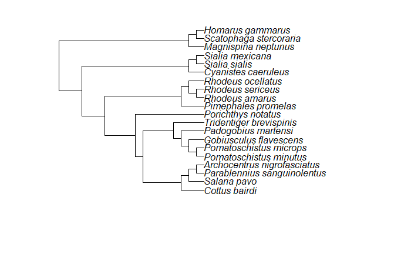

```r
tree1 <- read.tree('mytree1_mod.tre')
plot(tree1)
```

### Calculating the correlation matrix, with weighted values for relatedness

```r
tree1_mod <- compute.brlen(tree1, method="Grafen")
cor <- vcv(tree1_mod, corr =T)
```

### Cheking if every specie in the data is present in the tree

```r
spp <- data.frame(spp = unique(dataset1$phylo))
row.names(spp) <- spp$spp
```

```r
check.phylo <- name.check(tree1_mod, spp)
check.phylo
```

```
[1] "OK"
```

## Transforming r in Fisher’s Z

In our table we have values of r, here we transform to Z

```r
dataset1 <- escalc(measure="ZCOR", ri=r, ni=N, data=dataset1, append=TRUE)
attach(dataset1) # Just attaching each collumn
```

# Selecting the random-effects based on AICc

Randon variables: the effect size identity (id.mc), the article identity(nID), species (species) and the phylogenetic effect (phylo). Without moderators here.

### Creating an object for list each effect size

```r
id.mc <- as.factor(1:(length(dataset1$r)))
```

### Constructing models

```r
# id |--> AICc = 94.8374
m_randon1 <- rma.mv(yi=yi, V=vi, random = list(~ 1|id.mc), data=dataset1, method="ML")
summary(m_randon1)
```

```
Multivariate Meta-Analysis Model (k = 51; method: ML)

  logLik  Deviance       AIC       BIC      AICc
-45.2937  190.7031   94.5874   98.4510   94.8374

Variance Components:

            estim    sqrt  nlvls  fixed  factor
sigma^2    0.3129  0.5594     51     no   id.mc

Test for Heterogeneity:
Q(df = 50) = 2130.6210, p-val < .0001

Model Results:

estimate      se    zval    pval   ci.lb   ci.ub
  0.1634  0.0826  1.9776  0.0480  0.0015  0.3253  *

---
Signif. codes:  0 *** 0.001 ** 0.01 * 0.05 . 0.1   1
```

```r
# id + phylo |--> AICc = 97.0980
m_randon2 <- rma.mv(yi=yi, V=vi, random = list(~ 1|id.mc, ~1|phylo),R=list(phylo=cor), data=dataset1, method="ML")
summary(m_randon2)
```

```
Multivariate Meta-Analysis Model (k = 51; method: ML)

  logLik  Deviance       AIC       BIC      AICc
-45.2937  190.7031   96.5874  102.3829   97.0980

Variance Components:

            estim    sqrt  nlvls  fixed  factor    R
sigma^2.1  0.3129  0.5594     51     no   id.mc   no
sigma^2.2  0.0000  0.0000     20     no   phylo  yes

Test for Heterogeneity:
Q(df = 50) = 2130.6210, p-val < .0001

Model Results:

estimate      se    zval    pval   ci.lb   ci.ub
  0.1634  0.0826  1.9776  0.0480  0.0015  0.3253  *

---
Signif. codes:  0 *** 0.001 ** 0.01 * 0.05 . 0.1   1
```

```r
# id + species |--> AICc = 97.0980
m_randon3 <- rma.mv(yi=yi, V=vi, random = list(~ 1|id.mc, ~1|species), data=dataset1, method="ML")
summary(m_randon3)
```

```
Multivariate Meta-Analysis Model (k = 51; method: ML)

  logLik  Deviance       AIC       BIC      AICc
-45.2937  190.7031   96.5874  102.3829   97.0980

Variance Components:

            estim    sqrt  nlvls  fixed   factor
sigma^2.1  0.3129  0.5594     51     no    id.mc
sigma^2.2  0.0000  0.0000     20     no  species

Test for Heterogeneity:
Q(df = 50) = 2130.6210, p-val < .0001

Model Results:

estimate      se    zval    pval   ci.lb   ci.ub
  0.1634  0.0826  1.9776  0.0480  0.0015  0.3253  *

---
Signif. codes:  0 *** 0.001 ** 0.01 * 0.05 . 0.1   1
```

```r
# id + nID |--> AICc = 97.0980
m_randon4 <- rma.mv(yi=yi, V=vi, random = list(~ 1|id.mc, ~1|nID), data=dataset1, method="ML")
summary(m_randon4)
```

```
Multivariate Meta-Analysis Model (k = 51; method: ML)

  logLik  Deviance       AIC       BIC      AICc
-45.2937  190.7031   96.5874  102.3829   97.0980

Variance Components:

            estim    sqrt  nlvls  fixed  factor
sigma^2.1  0.3129  0.5594     51     no   id.mc
sigma^2.2  0.0000  0.0000     25     no     nID

Test for Heterogeneity:
Q(df = 50) = 2130.6210, p-val < .0001

Model Results:

estimate      se    zval    pval   ci.lb   ci.ub
  0.1634  0.0826  1.9776  0.0480  0.0015  0.3253  *

---
Signif. codes:  0 *** 0.001 ** 0.01 * 0.05 . 0.1   1
```

```r
# id + specie + phylo |--> AICc = 99.4569
m_randon5 <- rma.mv(yi=yi, V=vi, random = list(~ 1|id.mc, ~1|species, ~1|phylo), R=list(phylo=cor), data=dataset1, method="ML")
summary(m_randon5)
```

```
Multivariate Meta-Analysis Model (k = 51; method: ML)

  logLik  Deviance       AIC       BIC      AICc
-45.2937  190.7031   98.5874  106.3147   99.4569

Variance Components:

            estim    sqrt  nlvls  fixed   factor    R
sigma^2.1  0.3129  0.5594     51     no    id.mc   no
sigma^2.2  0.0000  0.0000     20     no  species   no
sigma^2.3  0.0000  0.0000     20     no    phylo  yes

Test for Heterogeneity:
Q(df = 50) = 2130.6210, p-val < .0001

Model Results:

estimate      se    zval    pval   ci.lb   ci.ub
  0.1634  0.0826  1.9776  0.0480  0.0015  0.3253  *

---
Signif. codes:  0 *** 0.001 ** 0.01 * 0.05 . 0.1   1
```

```r
# id + nID + specie |--> AICc = 99.4569
m_randon6 <- rma.mv(yi=yi, V=vi, random = list(~ 1|id.mc, ~1|nID, ~1|species), data=dataset1, method="ML")
summary(m_randon6)
```

```
Multivariate Meta-Analysis Model (k = 51; method: ML)

  logLik  Deviance       AIC       BIC      AICc
-45.2937  190.7031   98.5874  106.3147   99.4569

Variance Components:

            estim    sqrt  nlvls  fixed   factor
sigma^2.1  0.3129  0.5594     51     no    id.mc
sigma^2.2  0.0000  0.0000     25     no      nID
sigma^2.3  0.0000  0.0000     20     no  species

Test for Heterogeneity:
Q(df = 50) = 2130.6210, p-val < .0001

Model Results:

estimate      se    zval    pval   ci.lb   ci.ub
  0.1634  0.0826  1.9776  0.0480  0.0015  0.3253  *

---
Signif. codes:  0 *** 0.001 ** 0.01 * 0.05 . 0.1   1
```

```r
# id + nID + phylo |--> AICc = 99.4569
m_randon7 <- rma.mv(yi=yi, V=vi, random = list(~ 1|id.mc, ~1|nID, ~1|phylo),R=list(phylo=cor), data=dataset1, method="ML")
summary(m_randon7)
```

```
Multivariate Meta-Analysis Model (k = 51; method: ML)

  logLik  Deviance       AIC       BIC      AICc
-45.2937  190.7031   98.5874  106.3147   99.4569

Variance Components:

            estim    sqrt  nlvls  fixed  factor    R
sigma^2.1  0.3129  0.5594     51     no   id.mc   no
sigma^2.2  0.0000  0.0000     25     no     nID   no
sigma^2.3  0.0000  0.0000     20     no   phylo  yes

Test for Heterogeneity:
Q(df = 50) = 2130.6210, p-val < .0001

Model Results:

estimate      se    zval    pval   ci.lb   ci.ub
  0.1634  0.0826  1.9776  0.0480  0.0015  0.3253  *

---
Signif. codes:  0 *** 0.001 ** 0.01 * 0.05 . 0.1   1
```

```r
# id + nID + specie + phylo |--> AICc = 101.9207
m_randon8 <- rma.mv(yi=yi, V=vi, random = list(~ 1|id.mc, ~1|nID, ~1|species, ~1|phylo), R=list(phylo=cor), data=dataset1, method="ML")
summary(m_randon8)
```

```
Multivariate Meta-Analysis Model (k = 51; method: ML)

  logLik  Deviance       AIC       BIC      AICc
-45.2937  190.7031  100.5874  110.2465  101.9207

Variance Components:

            estim    sqrt  nlvls  fixed   factor    R
sigma^2.1  0.3129  0.5594     51     no    id.mc   no
sigma^2.2  0.0000  0.0000     25     no      nID   no
sigma^2.3  0.0000  0.0000     20     no  species   no
sigma^2.4  0.0000  0.0000     20     no    phylo  yes

Test for Heterogeneity:
Q(df = 50) = 2130.6210, p-val < .0001

Model Results:

estimate      se    zval    pval   ci.lb   ci.ub
  0.1634  0.0826  1.9776  0.0480  0.0015  0.3253  *

---
Signif. codes:  0 *** 0.001 ** 0.01 * 0.05 . 0.1   1
```

### Creating a table to compare models, looking for AICc

```r
ICtab(m_randon1, m_randon2, m_randon3, m_randon4, m_randon5, m_randon7, m_randon8, type= "AICc")
```

```
          dAICc df
m_randon1 0.0   2
m_randon3 2.3   3
m_randon4 2.3   3
m_randon2 2.3   3
m_randon7 4.6   4
m_randon5 4.6   4
m_randon8 7.1   5
```

# Performing - data set 1 - MALE-MALE COMPETITION

## The meta-analytic model

Randon variables included: the effect size identity (id.mc), the article identity(nID), species (species) and the phylogenetic effect (phylo). Without moderators here.

```r
meta.mc.phylo <- rma.mv(yi=yi, V=vi, random = list(~ 1|id.mc, ~1|nID, ~1|species, ~1|phylo), R=list(phylo=cor) , data=dataset1, method="REML")
```

### Looking the results

```r
summary(meta.mc.phylo)
```

```
Multivariate Meta-Analysis Model (k = 51; method: REML)

  logLik  Deviance       AIC       BIC      AICc
-44.8974   89.7948   99.7948  109.3550  101.1585

Variance Components:

            estim    sqrt  nlvls  fixed   factor    R
sigma^2.1  0.3197  0.5655     51     no    id.mc   no
sigma^2.2  0.0000  0.0000     25     no      nID   no
sigma^2.3  0.0000  0.0000     20     no  species   no
sigma^2.4  0.0000  0.0000     20     no    phylo  yes

Test for Heterogeneity:
Q(df = 50) = 2130.6210, p-val < .0001

Model Results:

estimate      se    zval    pval    ci.lb   ci.ub
  0.1633  0.0834  1.9571  0.0503  -0.0002  0.3268  .

---
Signif. codes:  0 *** 0.001 ** 0.01 * 0.05 . 0.1   1
```

### Overall effect and CI converted back to “r”

```r
predict(meta.mc.phylo, transf=transf.ztor)
```

```
   pred   ci.lb  ci.ub   cr.lb  cr.ub
 0.1619 -0.0002 0.3157 -0.7429 0.8574
```

### Basic forest plot (made with metafor package)

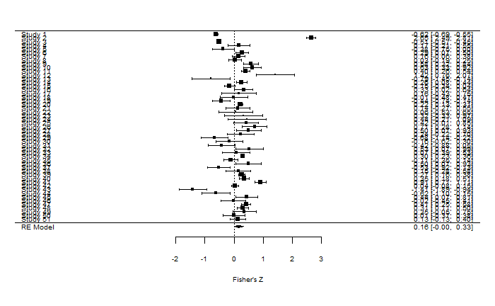

```r
forest(meta.mc.phylo, cex=.6, xlab="Fisher's Z")
```

## Heterogeinity

*Based in Nakagawa & Santos (2012)*

```r
s2m.mc <- sum(1/meta.mc.phylo$vi) * (meta.mc.phylo$k-1) / (sum(1/meta.mc.phylo$vi)^2 - sum((1/meta.mc.phylo$vi)^2))
s2m.mc #s^2_m variation within study
```

```
[1] 0.009171456
```

```r
s2t.mc <- sum(meta.mc.phylo$sigma2) + s2m.mc
s2t.mc #s^2_t variation total
```

```
[1] 0.3289146
```

### The total amount of variance

```r
total_I2.mc <- sum(meta.mc.phylo$sigma2)/s2t.mc
total_I2.mc*100 # the "total" variation
```

```
[1] 97.2116
```

### Proportion of variance from effect size id

```r
id.mc_I2 <- meta.mc.phylo$sigma2[1]/s2t.mc
id.mc_I2*100
```

```
[1] 97.2116
```

### Proportion of variance from study id

```r
nID_I2 <- meta.mc.phylo$sigma2[2]/s2t.mc
nID_I2*100
```

```
[1] 1.45785e-08
```

### Proportion of variance from species id

```r
especies_I2 <- meta.mc.phylo$sigma2[3]/s2t.mc
especies_I2*100
```

```
[1] 1.07295e-07
```

### Proportion of variance from phylo

```r
phylo_I2 <- meta.mc.phylo$sigma2[4]/s2t.mc
phylo_I2*100
```

```
[1] 1.33382e-09
```

## The phylogenetic effect

Very low, in this case.

```r
H2.mc<-meta.mc.phylo$sigma2[4] / sum(meta.mc.phylo$sigma2)
H2.mc*100
```

```
[1] 1.372079e-09
```

## Qb

Testing if the mean effect is different in different taxa.

```r
mean_taxon <- rma.mv(yi=yi, V=vi, random = list(~ 1|id.mc, ~1|nID, ~1|species, ~1|phylo), R=list(phylo=cor) , data=dataset1, method="REML", mod= ~ taxon-1)
summary(mean_taxon)
```

```
Multivariate Meta-Analysis Model (k = 51; method: REML)

  logLik  Deviance       AIC       BIC      AICc
-44.0363   88.0725  102.0725  115.1709  104.8725

Variance Components:

            estim    sqrt  nlvls  fixed   factor    R
sigma^2.1  0.3336  0.5776     51     no    id.mc   no
sigma^2.2  0.0000  0.0000     25     no      nID   no
sigma^2.3  0.0000  0.0000     20     no  species   no
sigma^2.4  0.0000  0.0000     20     no    phylo  yes

Test for Residual Heterogeneity:
QE(df = 48) = 1761.4116, p-val < .0001

Test of Moderators (coefficient(s) 1:3):
QM(df = 3) = 3.8223, p-val = 0.2813

Model Results:

              estimate      se    zval    pval    ci.lb   ci.ub
taxon1_artro    0.2281  0.2086  1.0935  0.2742  -0.1807  0.6369
taxon2_pisc     0.1448  0.0980  1.4775  0.1396  -0.0473  0.3369
taxon4_ave      0.1997  0.2998  0.6661  0.5053  -0.3879  0.7873

---
Signif. codes:  0 *** 0.001 ** 0.01 * 0.05 . 0.1   1
```

# Testing publication bias

## Egger’s regression

### Radial figure

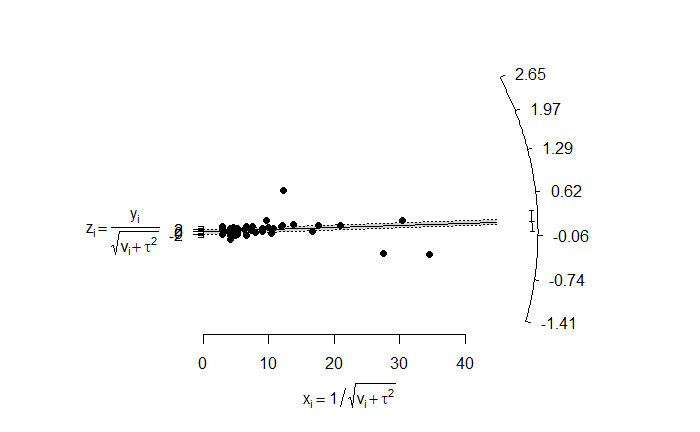

```r
# Egger's figure
radial.rma(meta.mc.phylo)
```

### Egger’s regression test

Non significant

```r
s.e.mc <- sqrt(dataset1$vi)
precision.mc <- 1/s.e.mc
Egger.mc <- lm(dataset1$yi*precision.mc ~ precision.mc)
summary(Egger.mc)
```

```
Call:
lm(formula = dataset1$yi * precision.mc ~ precision.mc)

Residuals:
    Min      1Q  Median      3Q     Max
-15.813  -1.975  -0.579   1.693  31.769

Coefficients:
             Estimate Std. Error t value Pr(>|t|)
(Intercept)    2.2709     1.4155   1.604    0.115
precision.mc  -0.1235     0.1303  -0.948    0.348

Residual standard error: 6.427 on 49 degrees of freedom
Multiple R-squared:  0.018, Adjusted R-squared:  -0.002043
F-statistic: 0.8981 on 1 and 49 DF,  p-value: 0.348
```

## Funnel Plot

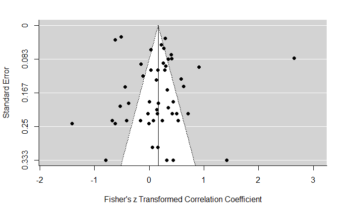

```r
# Basic funnel plot
funnel(meta.mc.phylo)
```

```r
#plot 1 ("plot")
plot(dataset1$yi,
precision.mc,
xlab="Fisher's Z",
ylab="precision (1/s.e.)",
cex=1.5,
xlim=c(min(dataset1$yi, na.rm=T)-0.5,max(dataset1$yi, na.rm=T)+0.5),
ylim=c(0,max(precision.mc, na.rm=T)*1.2))
abline(v=meta.mc.phylo[1], lwd=3)
```

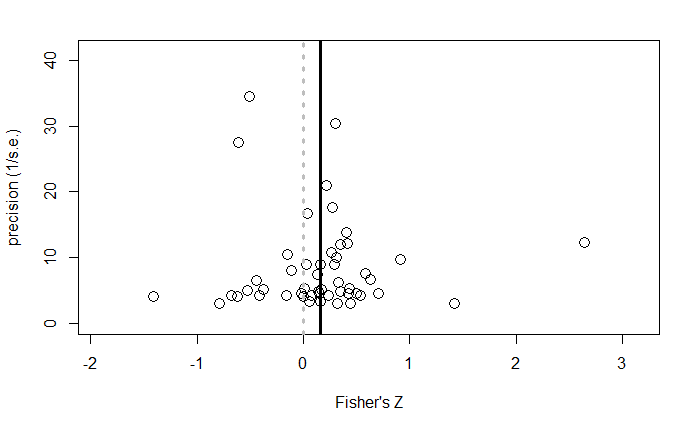

```r
abline(v=0, col=8, lwd=3, lty="dotted")
```

```r
#plot 2 ("ggplot")
dataset1$precision.mc <-precision.mc
funnel_1 <- ggplot(dataset1, aes(x=yi, y=precision.mc)) +
geom_point(size=4, colour="gray30") +
scale_shape(solid=FALSE) +
xlab(expression("Fisher's "*italic(Z))) +
ylab("precision (1/s.e.)") +
theme_classic(base_size = 23)+
geom_vline(xintercept=0, size=1.1, colour="gray", linetype = 1)+
geom_vline(xintercept=0.1663, size=1.1, linetype = 1)+
theme(axis.title.x=element_text(vjust=-0.1))+
theme(axis.title.y=element_text(vjust=1.2))
```

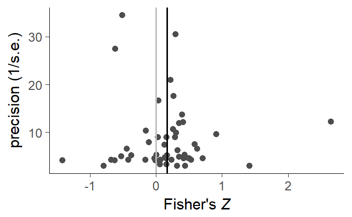

```r
funnel_1
```

# Moderators

## Type of methodological approach

Testing if differences between study methods (obs, exp_lab, exp_field) explain variance in data

```r
meta.mc_mod1 <- rma.mv(yi=yi, V=vi, random = list(~ 1|id.mc, ~1|nID, ~1|species, ~1|phylo), R=list(phylo=cor) , data=dataset1, method="REML", mod= ~ study_type-1)
summary(meta.mc_mod1)
```

```
Multivariate Meta-Analysis Model (k = 51; method: REML)

  logLik  Deviance       AIC       BIC      AICc
-43.1873   86.3747  100.3747  113.4731  103.1747

Variance Components:

            estim    sqrt  nlvls  fixed   factor    R
sigma^2.1  0.3206  0.5662     51     no    id.mc   no
sigma^2.2  0.0000  0.0000     25     no      nID   no
sigma^2.3  0.0000  0.0000     20     no  species   no
sigma^2.4  0.0000  0.0000     20     no    phylo  yes

Test for Residual Heterogeneity:
QE(df = 48) = 2010.0440, p-val < .0001

Test of Moderators (coefficient(s) 1:3):
QM(df = 3) = 5.6949, p-val = 0.1274

Model Results:

                     estimate      se    zval    pval    ci.lb   ci.ub
study_typeexp_field    0.3080  0.1405  2.1921  0.0284   0.0326  0.5834  *
study_typeexp_lab      0.0570  0.1181  0.4832  0.6290  -0.1744  0.2884
study_typeobs          0.1772  0.2187  0.8102  0.4179  -0.2514  0.6057

---
Signif. codes:  0 *** 0.001 ** 0.01 * 0.05 . 0.1   1
```

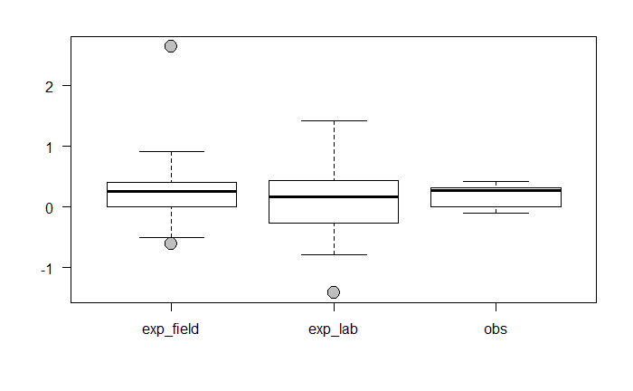

```r
plot(dataset1$study_type, dataset1$yi, las = 1, bty = "l", cex = 2, pch=21, bg=16)
```

```r
table(dataset1$study_type)
```

```
exp_field   exp_lab       obs
       17        27         7
```

## Type of mating system

Testing if differences between monogamy and polygamy mating systems explain variance in data

```r
# mating_system/social_bond
meta.mc_mod22 <- rma.mv(yi=yi, V=vi, random = list(~ 1|id.mc, ~1|nID, ~1|species, ~1|phylo), R=list(phylo=cor) , data=dataset1, method="REML", mod= ~ mating_system-1)
summary(meta.mc_mod22)
```

```
Multivariate Meta-Analysis Model (k = 51; method: REML)

  logLik  Deviance       AIC       BIC      AICc
-44.4242   88.8484  100.8484  112.1993  102.8484

Variance Components:

            estim    sqrt  nlvls  fixed   factor    R
sigma^2.1  0.3257  0.5707     51     no    id.mc   no
sigma^2.2  0.0000  0.0000     25     no      nID   no
sigma^2.3  0.0000  0.0000     20     no  species   no
sigma^2.4  0.0000  0.0000     20     no    phylo  yes

Test for Residual Heterogeneity:
QE(df = 49) = 2115.9187, p-val < .0001

Test of Moderators (coefficient(s) 1:2):
QM(df = 2) = 3.8959, p-val = 0.1426

Model Results:

                       estimate      se    zval    pval    ci.lb   ci.ub
mating_systemmonogamy    0.0859  0.2271  0.3781  0.7053  -0.3593  0.5311
mating_systempolygamy    0.1755  0.0906  1.9372  0.0527  -0.0021  0.3530  .

---
Signif. codes:  0 *** 0.001 ** 0.01 * 0.05 . 0.1   1
```

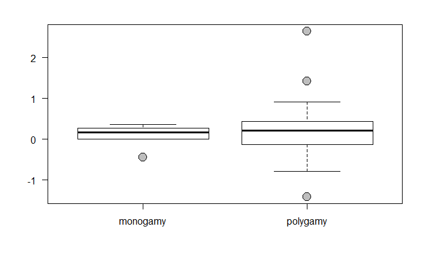

```r
plot(dataset1$mating_system, dataset1$yi, las = 1, bty = "l", cex = 2, pch=21, bg=16)
```

```r
table(dataset1$mating_system)
```

```
monogamy polygamy
       7       44
```

## Type of parental care

Testing if differences between parental care type (maternal, paternal, biparental, no_care) explain variance in data

```r
meta.mc_mod3 <- rma.mv(yi=yi, V=vi, random = list(~ 1|id.mc, ~1|nID, ~1|species, ~1|phylo), R=list(phylo=cor) , data=dataset1, method="REML", mod= ~ care-1)
summary(meta.mc_mod3)
```

```
Multivariate Meta-Analysis Model (k = 51; method: REML)

  logLik  Deviance       AIC       BIC      AICc
-43.0881   86.1761  102.1761  116.9773  105.9656

Variance Components:

            estim    sqrt  nlvls  fixed   factor    R
sigma^2.1  0.3333  0.5773     51     no    id.mc   no
sigma^2.2  0.0000  0.0000     25     no      nID   no
sigma^2.3  0.0000  0.0000     20     no  species   no
sigma^2.4  0.0000  0.0000     20     no    phylo  yes

Test for Residual Heterogeneity:
QE(df = 47) = 1713.2816, p-val < .0001

Test of Moderators (coefficient(s) 1:4):
QM(df = 4) = 4.7985, p-val = 0.3086

Model Results:

                estimate      se     zval    pval    ci.lb   ci.ub
carebiparental    0.0920  0.2141   0.4297  0.6674  -0.3276  0.5115
carematernal     -0.1026  0.4303  -0.2383  0.8116  -0.9460  0.7409
careno_care       0.0995  0.1546   0.6436  0.5198  -0.2035  0.4026
carepaternal      0.2445  0.1201   2.0354  0.0418   0.0091  0.4800  *

---
Signif. codes:  0 *** 0.001 ** 0.01 * 0.05 . 0.1   1
```

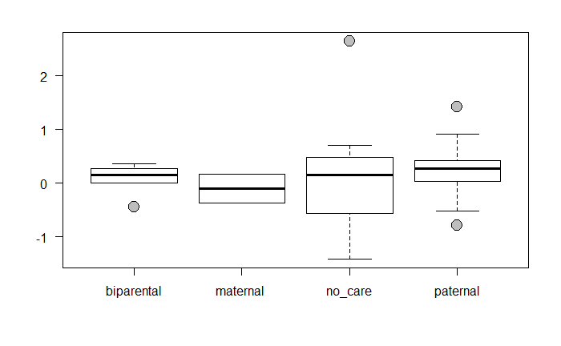

```r
plot(dataset1$care, dataset1$yi, las = 1, bty = "l", cex = 2, pch=21, bg=16)
```

```r
table(dataset1$care)
```

```
biparental  maternal     no_care   paternal
         8          2         16         25
```

## Type of competition

Testing if there is difference between direct(agonistic behaviour) and indirect (rate of use, occupation, etc) competition for resorces explain part of variance

```r
# pred
meta.mc_mod4 <- rma.mv(yi=yi, V=vi, random = list(~ 1|id.mc, ~1|nID, ~1|species, ~1|phylo), R=list(phylo=cor) , data=dataset1, method="REML", mod= ~ pred-1)
summary(meta.mc_mod4)
```

```
Multivariate Meta-Analysis Model (k = 51; method: REML)

  logLik  Deviance       AIC       BIC      AICc
-44.2002   88.4004  100.4004  111.7513  102.4004

Variance Components:

            estim    sqrt  nlvls  fixed   factor    R
sigma^2.1  0.3217  0.5672     51     no    id.mc   no
sigma^2.2  0.0000  0.0000     25     no      nID   no
sigma^2.3  0.0000  0.0000     20     no  species   no
sigma^2.4  0.0000  0.0000     20     no    phylo  yes

Test for Residual Heterogeneity:
QE(df = 49) = 1740.8933, p-val < .0001

Test of Moderators (coefficient(s) 1:2):
QM(df = 2) = 4.4129, p-val = 0.1101

Model Results:

         estimate      se    zval    pval    ci.lb   ci.ub
preddir    0.1112  0.1071  1.0381  0.2992  -0.0988  0.3212
predind    0.2446  0.1340  1.8262  0.0678  -0.0179  0.5072  .

---
Signif. codes:  0 *** 0.001 ** 0.01 * 0.05 . 0.1   1
```

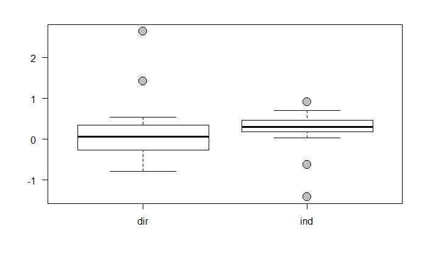

```r
plot(dataset1$pred, dataset1$yi, las = 1, bty = "l", cex = 2, pch=21, bg=16)
```

```r
table(dataset1$pred)
```

```
dir ind
 32  19
```

# Making a better forest plot

First, creating a new data frame, with colunms with the confidence interval

```r
mean.effect <- as.data.frame(matrix(t(mean.effect),nrow=1),stringsAsFactors=FALSE)
class(mean.effect)
```

```
[1] "data.frame"
```

```r
df1.1$yi <- as.character(df1.1$yi)
df1.1$CILB <- as.character(df1.1$CILB)
df1.1$CIUB <- as.character(df1.1$CIUB)
```

```r
df1.1$yi <- as.numeric(df1.1$yi)
df1.1$CILB <- as.numeric(df1.1$CILB)
df1.1$CIUB <- as.numeric(df1.1$CIUB)
```

```r
highlight <- subset(df1.1, ES=="Mean effect size")
```

Now, creating the plot

```r
myplot_1 <- ggplot(df1.1, aes(x=ES)) +
  geom_hline(aes(yintercept=0), linetype="dashed", color="gray", lwd=1) +
  geom_linerange(aes(x=ES, ymin=CILB, ymax=CIUB),col="gray50", lwd=1, alpha=0.7) +
  geom_linerange(aes(x=ES, ymin=CILB, ymax=CIUB), data=highlight, colour="black") +
  geom_point(aes(y=yi, size=yi), shape = 21, fill="gray50", col="gray50") +
  geom_point(aes(y=yi, size=yi), data=highlight, colour="black") +
  scale_size_continuous(range = c(1,5), name="Effect size Zr") +
  scale_x_discrete(limits = rev(levels(df1.1$ES)))+
  ylab(expression(Effect~Size~italic(Zr)))+
  xlab("")+
  theme_bw()+
  coord_flip()+
  guides(fill= guide_legend(override.aes = list(size=5)),
         size = guide_legend(override.aes = list(fill = "gray40")))+
  theme(panel.border = element_blank(),
        panel.grid.major = element_blank(),
        panel.grid.minor = element_blank(),
        axis.text.x = element_text(size=12),
        axis.text.y = element_text(size=10),
        axis.line = element_line(colour = "black"),
        legend.position = "none")
```

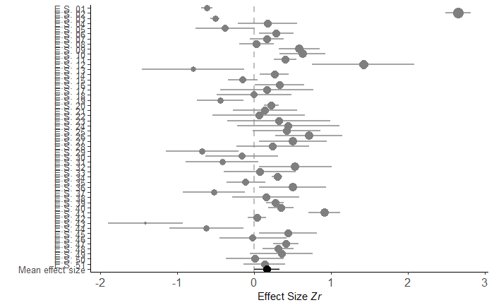

```r
myplot_1
```